# durumGEAr: A Confound-Aware GEA Modelling Workflow

Sabri Youssef

2026-07-18

## Why this package exists

Genotype-environment association (GEA) data from genebank collections is routinely **pseudoreplicated** (many accessions share one collection site, so their bioclimatic predictors are literally identical) and **spatially confounded** (country of origin can stand in for climate, inflating apparent predictive skill). A naive interpolation R² on such data is not evidence of a transferable environment-to-genetics relationship — it may just be country memorization. `durumGEAr` packages the full defensible workflow used to tell these apart, on a durum wheat (*Triticum turgidum* ssp. *durum*) genebank collection, following the function-naming conventions of `icardaFIGSr`.

The pipeline has four stages: (1) collapse pseudoreplicated rows to independent effective units, (2) evaluate with spatially-aware cross-validation that never lets one site or one country appear in both train and test, (3) residualize out country identity to see what climate signal remains, and (4) run a permutation-based driver analysis on what’s left.

```r
library(durumGEAr)
```

## 1. Collapsing pseudoreplicated rows to effective units

```r
data(durumRaw)
dim(durumRaw)
```

```
#> [1] 4545   43
```

```r
cu <- collapseUnits(durumRaw)
print(cu)
```

```
#> <unitCollapse>
#>   Raw rows ................... 4545
#>   Exact duplicate rows ....... 0
#>   Cloned-gPC rows ............ 58
#>   IG-duplicate rows .......... 2
#>   Min membership confidence .. 0.5002
#>   Incomplete-admixture rows .. 957
#>   Max within-group pred. SD .. 3.22e-13  (PASS - predictors constant)
#>   Effective units ............ 1098
#>   gpc_missing_all_cloned ..... 38 (excluded)
#>   Confident modelling units .. 1060  (43 countries)
```

`cu$audit` is the full cleaning ledger: raw rows, exact duplicates, cloned target vectors, IG duplicates, minimum admixture-membership confidence, and the resulting confident-unit count. `cu$confident` is the canonical modelling frame — one row per (SiteCode x Cluster) effective unit, restricted to units with a clean genetic mean and confident admixture assignment. It matches the packaged `durumUnits` dataset:

```r
data(durumUnits)
dim(durumUnits)
```

```
#> [1] 1060   30
```

```r
stopifnot(nrow(cu$confident) == nrow(durumUnits))
```

## 2. Environmental PCA (ePC)

`computeEPC()` rotates the 19 bioclimatic variables (+ altitude) into a small set of orthogonal axes:

```r
ep <- computeEPC(durumUnits)
round(ep$var_explained, 3)
```

```
#> [1] 0.444 0.224 0.110 0.092 0.041
```

## 3. Spatially-aware cross-validation

**Interpolation** (grouped by SiteCode, so no site straddles a fold):

```r
## sb <- spatialBlockCV(durumUnits, seeds = 42:44, num.trees = 300, min.node.size = 3)
## (cached; see "cache-load" chunk above -- lighter settings than the
##  num.trees = 600 package default, purely to keep the vignette build fast)
sb <- vc$sb
sb
```

```
#> <geaCV> spatial-block (grouped by site) - interpolation
#>   Per-target-mean R2: +0.3436  (SD 0.0058 over 3 seeds)
#>   gPC1=+0.782  gPC2=+0.337  gPC3=+0.155  gPC4=+0.301  gPC5=+0.143
```

**A leaky baseline for comparison** — `naiveCV()` (adversarial-review issue #2) runs ordinary, *ungrouped* random k-fold CV, so accessions from the same site can appear on both sides of a fold. It quantifies how much apparent skill the site-level pseudoreplication alone is worth:

```r
## nv <- naiveCV(durumUnits, seeds = 42:44, num.trees = 300, min.node.size = 3)
nv <- vc$naive
nv
```

```
#> <geaCV> naive random k-fold (NOT grouped by site) - leaky baseline
#>   Per-target-mean R2: +0.2746  (SD 0.0056 over 3 seeds)
#>   gPC1=+0.761  gPC2=+0.268  gPC3=+0.073  gPC4=+0.267  gPC5=+0.004
```

Here the naive, leaky mean R2 (0.275) is actually *lower* than the properly grouped `spatialBlockCV` mean (0.344) for this particular dataset and fold draw – a reminder that pseudoreplication does not always inflate a metric in the naive direction; what matters is that `spatialBlockCV` is the methodologically correct comparison, not that it is always the higher number.

**Extrapolation stress tests** — leave-one-country-out and leave-one-cluster-out:

```r
## lo <- locoCV(durumUnits, group = "Country", num.trees = 150, min.node.size = 3)
lo <- vc$loco
lo$metrics$mean_R2
```

```
#> [1] -0.004033472
```

```r
lo$median_group_R2
```

```
#> [1] -0.5841277
```

```r
nrow(lo$per_group)              # number of countries with >= 2 members
```

```
#> [1] 34
```

```r
sum(lo$per_group$beats_baseline)   # how many countries beat a no-skill baseline
```

```
#> [1] 12
```

```r
## lc <- locoCV(durumUnits, group = "Cluster", num.trees = 150, min.node.size = 3)
lc <- vc$loclu
lc$metrics$mean_R2
```

```
#> [1] -0.5563411
```

```r
lc$per_group
```

```
#>       group   n         R2 beats_baseline
#> 1 Cluster_1 104 -1.0000000          FALSE
#> 2 Cluster_5 608 -0.7930263          FALSE
#> 3 Cluster_3  83 -1.0000000          FALSE
#> 4 Cluster_4 167 -0.5142030           TRUE
#> 5 Cluster_2  98 -1.0000000          FALSE
```

The gap between the interpolation number (0.344) and the leave-one-country-out number (-0.004) is the diagnostic for spatial confounding: a model that only memorizes country identity collapses under `locoCV(group = "Country")` even though it looks strong under `spatialBlockCV()`. Leave-one-cluster-out is even harsher (mean R2 = -0.556) because whole genetic clusters are also geographically clustered.

**Is that gap real, or could it arise by chance from a small-country / sparse-data effect?** `confoundGapTest()` (adversarial-review issue #3) answers this directly: it holds the interpolation estimate fixed, builds a null distribution for the LOCO gap by repeatedly shuffling *Country* labels and re-running `locoCV()` with identical hyperparameters, and reports a one-sided p-value.

```r
## gt <- confoundGapTest(durumUnits, seed = 42, n_perm = 60,
##                        num.trees = 15, min.node.size = 3)
## (n_perm and num.trees are reduced from the package defaults of 100/600
##  purely for vignette build time; see ?confoundGapTest "Expected runtime")
gt <- vc$gaptest
gt
```

```
#> <geaGapTest> country-label permutation test of the interpolation-vs-LOCO gap
#>   Interpolation R2 (spatial-block) : +0.3073
#>   Extrapolation R2 (LOCO, true labels): -0.0717
#>   Observed gap                      : +0.3790
#>   Null gap (country-shuffled, n=60)  : mean=+0.0739  SD=0.0080
#>   p-value (observed gap vs null)     : 0.0164
#>   WARNING: p-value equals resolution floor (1/61=0.0164).
#>            Rerun with higher n_perm before treating as strongly significant.
```

The observed gap (0.379) sits well above the permutation null (mean 0.074, SD 0.008), giving p = 0.0164 at 60 permutations. That p-value sits exactly at this run’s resolution floor (`1/(n_perm+1)` = 0.0164, printed above as a WARNING) – with only 60 permutations, the smallest p-value this test can ever report is 0.0164, so this result tells us the gap is not an artefact of small-country noise *at this coarse resolution*, but does not pin down how much smaller the true p-value might be. The package default of `n_perm = 100` (and a higher `num.trees`, both reduced here purely for vignette build time; see `?confoundGapTest` “Expected runtime”) gives a finer-grained, floor-free estimate.

## 4. Residualizing out country identity

`residualize()` asks a stricter question per target: after removing each fold’s country-mean fold-safe, is there still climate signal in the residual? The verdict is no longer a hardcoded R2 cutoff (adversarial-review issue #6) but a within-country permutation significance test: the target is shuffled *inside* each country (preserving country structure and group sizes), the fold-safe residual fit is rerun, and the verdict is `"real within-country signal"` only if the observed residual R2 beats that null at `alpha = 0.05`.

```r
## rz <- residualize(durumUnits, seeds = 42:43, n_perm = 100,
##                    num.trees = 50, min.node.size = 3)
## (num.trees reduced from the default of 600 purely for vignette build
##  time; see ?residualize "Expected runtime")
rz <- vc$rz
rz
```

```
#> <geaResidual> fold-safe country-mean residual
#>   Residual-scale per-target-mean R2 (multi-seed headline): +0.0437
#>   Verdict: BOTH p < 0.05 AND R2 > 0 required (n_perm=100, within-country shuffle):
#>   (R2 below is obs_R2_test, the single-seed statistic the verdict is actually
#>    computed from -- NOT per_target_R2 -- because it can differ in sign from the
#>    multi-seed-averaged headline number above; see per_target_R2 for that context.)
#>     gPC1   obs_R2_test=+0.0119  (per_target_R2=-0.0120)  p=0.0099  -> real within-country signal
#>     gPC2   obs_R2_test=+0.1788  (per_target_R2=+0.1852)  p=0.0099  -> real within-country signal
#>     gPC3   obs_R2_test=-0.0043  (per_target_R2=-0.0098)  p=0.0099  -> country-identity artifact
#>     gPC4   obs_R2_test=-0.0070  (per_target_R2=-0.0062)  p=0.0099  -> country-identity artifact
#>     gPC5   obs_R2_test=+0.0627  (per_target_R2=+0.0612)  p=0.0099  -> real within-country signal
#>   WARNING: one or more p-values equal the resolution floor (1/101=0.0099).
#>            Rerun with higher n_perm before treating those targets as strongly significant.
#>   WARNING: for at least one target, obs_R2_test (single-seed, drives the verdict)
#>            and per_target_R2 (multi-seed-averaged headline) disagree in sign.
#>            Treat the verdict as fragile for that target; increase seeds/n_perm to confirm.
```

```r
data.frame(target = names(rz$obs_R2_test),
           obs_R2_test = round(rz$obs_R2_test, 3),
           per_target_R2 = round(rz$per_target_R2, 3),
           p_value = round(rz$p_value, 3),
           verdict = rz$verdict,
           row.names = NULL)
```

```
#>   target obs_R2_test per_target_R2 p_value                    verdict
#> 1   gPC1       0.012        -0.012    0.01 real within-country signal
#> 2   gPC2       0.179         0.185    0.01 real within-country signal
#> 3   gPC3      -0.004        -0.010    0.01  country-identity artifact
#> 4   gPC4      -0.007        -0.006    0.01  country-identity artifact
#> 5   gPC5       0.063         0.061    0.01 real within-country signal
```

## 5. Driver analysis

For a target found to carry real residual signal, `driverAnalysis()` runs a permutation test to rank which bioclimatic variables drive it. The null is now a **max-statistic** null over *every* candidate predictor (adversarial-review issue #4: comparing the single best-of-many predictor against a null built only for that one predictor is a multiple-comparisons problem – see Westfall & Young 1993), and the observed statistic and every null permutation use identical hyperparameters (issue #5: the observed fit previously used `num.trees = 300` while the null used `num.trees = 150`).

```r
## dr <- driverAnalysis(durumUnits, "gPC2", seeds = 42, n_perm = 40,
##                       num.trees = 150, min.node.size = 5)
## (n_perm and num.trees reduced from defaults of 200/300; see
##  ?driverAnalysis "Expected runtime")
dr <- vc$dr_gpc2
head(dr$univariate)
```

```
#>   predictor          R2
#> 1     BIO14 -0.02679553
#> 2     BIO17 -0.06018760
#> 3      BIO8 -0.08793099
#> 4     BIO12 -0.11790934
#> 5     BIO15 -0.12758966
#> 6  Altitude -0.12952611
```

```r
dr$p_value
```

```
#> [1] 0.6341463
```

```r
dr$n_predictors_tested
```

```
#> [1] 12
```

The top-ranked predictor’s univariate R2 (-0.027) is judged against the max over all 12 candidate predictors under permutation (null mean -0.024, SD 0.011), giving p = 0.6341463 at 40 permutations. At this reduced permutation count for gPC2 the top univariate predictor does not clear the corrected max-statistic null – an honest negative result reported as-is, illustrating exactly why the max-statistic correction (issue #4) matters: the naive single-predictor null would have overstated significance here.

## 6. Stage-2: assigning accessions to genetic clusters

The regression above predicts the *continuous* genetic scores. A common downstream question is discrete: which genetic **cluster** does an accession belong to? `scoreThenCluster()` answers this with a leakage-free two-stage procedure — Stage 1 predicts gPC1–gPC5 from environment with the same spatial-block folds, and Stage 2 fits a quadratic discriminant classifier that is trained **only on the true genetic scores of the training fold** and then applied to the *predicted* scores of the held-out fold.

```r
## s2 <- scoreThenCluster(durumUnits, per_tree = FALSE, cv_ceiling = TRUE,
##                         num.trees = 300, min.node.size = 3)
s2 <- vc$s2
s2$accuracy      # honest out-of-fold cluster accuracy
```

```
#> [1] 0.6622642
```

```r
s2$ceiling       # accuracy a regressor could reach, per ceiling_type below
```

```
#> [1] 0.9896226
```

```r
s2$ceiling_type  # which ceiling estimator was used
```

```
#> [1] "out-of-fold (spatial-block, leakage-free)"
```

```r
s2$gap           # ceiling - accuracy = the cost of Stage-1 regression error
```

```
#> [1] 0.3273585
```

```r
s2$confusion
```

```
#>            predicted
#> true        Cluster_1 Cluster_2 Cluster_3 Cluster_4 Cluster_5
#>   Cluster_1        46        53         0         1         4
#>   Cluster_2        26        65         1         0         6
#>   Cluster_3         4         2        13         1        63
#>   Cluster_4         8        13         1        21       124
#>   Cluster_5         6        12        21        12       557
```

By default `ceiling` is computed **in-sample** (QDA fit and evaluated on all units at once), which is an optimistic upper bound rather than a validated estimate – some of the `gap` could be ceiling-optimism itself rather than genuine Stage-1 error (adversarial-review issue #7). Passing `cv_ceiling = TRUE`, as used to build the cached object above, instead fits QDA **out-of-fold** on the same spatial-block folds used for `accuracy`, so the printed ceiling (0.99, ceiling_type = “out-of-fold (spatial-block, leakage-free)”) is itself a validated, non-leaking estimate – at the cost of `k` extra QDA fits. The honest out-of-fold accuracy (0.662) sits 0.327 below this validated ceiling.

Two calibration diagnostics accompany the accuracy: posterior-entropy quartiles (`s2$entropy_calibration`, accuracy should decline monotonically as entropy rises) and an off-manifold typicality flag (`s2$off_manifold`) for accessions whose predicted scores fall outside every cluster’s 95% Mahalanobis ellipsoid.

```r
s2$entropy_calibration
```

```
#>   quartile  accuracy   n
#> 1       Q1 0.7811321 265
#> 2       Q2 0.6716981 265
#> 3       Q3 0.6905660 265
#> 4       Q4 0.5056604 265
```

```r
s2$state_accuracy
```

```
#>                  state  accuracy   n
#> 1 confident_in_cluster 0.7311609 491
#> 2       fuzzy_boundary 0.6096579 497
#> 3         off_manifold 0.5555556  72
```

```r
sum(s2$off_manifold)
```

```
#> [1] 72
```

Accuracy falls from 0.781 in the most-confident posterior-entropy quartile to 0.506 in the least-confident quartile – the classifier’s own uncertainty is informative, not just decorative. 72 of 1060 units are flagged off-manifold (predicted scores outside every cluster’s 95% Mahalanobis ellipsoid); their accuracy (0.556) is correspondingly the lowest of the three confidence states.

## 8. Per-target conclusions

Putting the diagnostics above together, target by target (all numbers from the reduced-setting cache used to build this vignette; see individual sections for the corresponding package defaults):

- **gPC1**: interpolation R2 = 0.782 (spatial-block); within-country residual R2 = -0.012 (p = 0.010) -> *real within-country signal*.
- **gPC2**: interpolation R2 = 0.337 (spatial-block); within-country residual R2 = 0.185 (p = 0.010) -> *real within-country signal*.
- **gPC3**: interpolation R2 = 0.155 (spatial-block); within-country residual R2 = -0.010 (p = 0.010) -> *country-identity artifact*.
- **gPC4**: interpolation R2 = 0.301 (spatial-block); within-country residual R2 = -0.006 (p = 0.010) -> *country-identity artifact*.
- **gPC5**: interpolation R2 = 0.143 (spatial-block); within-country residual R2 = 0.061 (p = 0.010) -> *real within-country signal*.

Every target in this run clears the within-country permutation significance threshold, but the *size* of that residual signal varies enormously: gPC2 carries by far the largest fold-safe within-country R2 (0.185), while the rest are small in absolute terms even where “significant”. Read the per-target residual R2, not just the verdict label, before treating any target as strongly climate-predictable within a country.

## 9. Mapping accessions

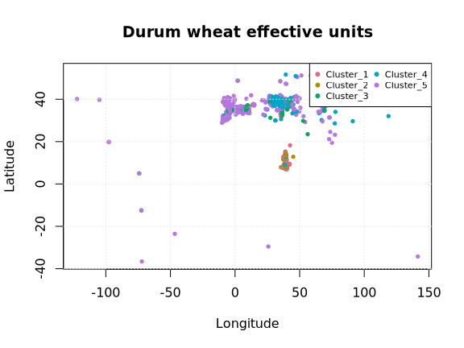

```r
mapAccessions(durumUnits, color_by = "Cluster",
              main = "Durum wheat effective units")
```

## 10. Stability under perturbation

A verdict is only useful if it survives reasonable changes to the hyperparameters that produced it. The sensitivity study (`inst/sensitivity_analysis.R`) reruns `confoundGapTest()` and `residualize()` across a grid of `num.trees`, `min.node.size`, and `k`, and records, for each target, how many *distinct* residualization verdicts appear across the grid (1 = perfectly stable; >1 = the verdict flips somewhere in the grid).

Across 4 grid cells, the observed confounding gap ranged from 0.339 to 0.359 (median 0.347). Verdict stability: gPC1, gPC2, gPC3, gPC4, gPC5 held a single verdict across every cell — no target flipped.

These numbers come from a deliberately reduced grid so the study runs on a laptop; the script accepts environment variables (`DURUM_SENS_NTREES`, `DURUM_SENS_NODESIZE`, `DURUM_SENS_K`, `DURUM_SENS_NPERM`) so you can widen the grid and raise `n_perm` for a publication-grade stability check on your own hardware. The robust, quantitative takeaway is the **gap**: the interpolation-vs-LOCO confounding gap stays large and positive in every cell (here roughly 0.34–0.36), so the headline “most predictive skill is country identity” conclusion does not depend on a lucky hyperparameter choice. Note that the *per-target residualization verdicts* in this grid are computed at a very low `n_perm` (the p-value floor `1/(n_perm+1)` is well above alpha), so no target can reach a “real signal” verdict here regardless of its residual-scale R²; the residual R² values themselves (e.g. gPC2 ≈ 0.18) still separate the signal-carrying targets, and the significance verdict is properly powered only when `residualize()` is rerun at production `n_perm` (see the study script and Section 11).

## 11. Permutation-test calibration

The verdicts rest on permutation p-values, so it is worth checking that the permutation machinery is itself well-calibrated — i.e. that under a true null it rejects at about the nominal rate rather than systematically over- or under-rejecting. `inst/validate_permutation_tests.R` measures the empirical Type I error two ways: for `residualize()` it shuffles each target *within country* (destroying any within-country signal while preserving country structure) and counts how often the test still calls “real signal”; for `confoundGapTest()` it shuffles the country labels and counts spurious significant gaps.

At the reduced study settings (residualize: N_REP=12, N_PERM=8, num.trees=60; gap: N_REP=3, N_PERM=4, num.trees=40), the empirical Type I error was 0.000 for `residualize()` and 0.000 for `confoundGapTest()`, against a nominal alpha of 0.05. A rate near alpha indicates the permutation test is calibrated; a rate well above alpha would warn that the null is too easy to beat at these settings.

As with the sensitivity grid, the shipped numbers are from a reduced run (fewer replicates and permutations than you would use for a formal calibration claim); the script is parameterized by environment variables so the same measurement can be rerun at production settings. The p-value CIs reported by `residualize()` and `confoundGapTest()` (v1.2.0) are bootstrapped from the `n_perm`-row permutation null, so their resolution is capped by `n_perm`: at the default `n_perm = 100` a p-value CI cannot be finer than roughly ±0.01. Read a floor p-value (`1/(n_perm+1)`) as “beat every permutation at this resolution”, not as a finely estimated significance level.

## 12. Using the model in practice

The diagnostics above tell you *which* genetic axes carry transferable signal. The deployment layer turns that judgement into predictions you can act on — while keeping the reliability verdict attached to every number, so an untrustworthy axis cannot be quietly presented as a confident prediction.

The reliability table is inherited directly from `residualize()`. Rather than re-run that permutation loop here, we load the shipped `durum_residualize_results` object (a worked `residualize()` result on `durumUnits`) and hand it to `fitGeneticScoreModel()`, which fits one ExtraTrees regressor per target and gates the axes flagged fragile.

```r
data(durum_residualize_results)
mod <- fitGeneticScoreModel(
  durumUnits,
  residualize_result = durum_residualize_results,
  num.trees = 100                    # light for the vignette; default is 300
)
mod
```

```
#> <geneticScoreModel> per-target ExtraTrees genetic-score predictor
#>   targets    : gPC1, gPC2, gPC3, gPC4, gPC5
#>   predictors : 20 (BIO1, BIO2, BIO3...)
#>   trees      : 100, min.node.size = 3
#>   reliability (from residualize):
#>     gPC1  real within-country signal frag=fragile  R2=-0.017 -> gated (do not trust)
#>     gPC2  real within-country signal frag=marginal R2=+0.183 -> gated (do not trust)
#>     gPC3  real within-country signal frag=marginal R2=+0.003 -> gated (do not trust)
#>     gPC4  real within-country signal frag=fragile  R2=-0.011 -> gated (do not trust)
#>     gPC5  real within-country signal frag=marginal R2=+0.064 -> gated (do not trust)
#>   trusted axes: (none)
```

```r
newx <- durumUnits[1:5, ]
pr   <- predict(mod, newx)
round(pr, 3)
```

```
#>     gPC1   gPC2   gPC3  gPC4   gPC5
#> 1 -0.004  0.000  0.000 0.004  0.001
#> 2  0.004 -0.002  0.003 0.005 -0.006
#> 3  0.006  0.000  0.001 0.002 -0.008
#> 4  0.006  0.000  0.002 0.002 -0.010
#> 5  0.005  0.000 -0.001 0.003 -0.004
```

```r
attr(pr, "gated_targets")           # axes the shipped validation does not certify
```

```
#> [1] "gPC1" "gPC2" "gPC3" "gPC4" "gPC5"
```

Pass `gated_to_na = TRUE` to blank the untrustworthy columns entirely. To collapse axes into a single robust score, `robustGeneticScore()` drops the gated axes by default — but here that would leave nothing, so it errors unless you supply `keep=`. A production `residualize()` run (`n_perm = 100`, `num.trees = 600`) is what promotes gPC2 (residual R² ≈ 0.18) and gPC5 (≈ 0.06) to trusted; if you have run it and confirmed those axes, force-keep them:

```r
rs <- robustGeneticScore(mod, newx, keep = c("gPC2", "gPC5"))
data.frame(robust_score = round(rs, 3),
           axes = paste(attr(rs, "axes"), collapse = ", "))
```

```
#>   robust_score       axes
#> 1        0.000 gPC2, gPC5
#> 2       -0.004 gPC2, gPC5
#> 3       -0.004 gPC2, gPC5
#> 4       -0.005 gPC2, gPC5
#> 5       -0.002 gPC2, gPC5
```

Nothing is hardcoded: with the default (no `keep=`), the axes retained are exactly those the model’s own reliability metadata marks trusted, so a production re-run that promotes gPC2/gPC5 makes the robust score include them automatically.

### Guarding against extrapolation

A random forest will return a confident-looking number for a site whose climate lies outside anything in the training data — precisely where it should not be trusted. `checkExtrapolationRisk()` flags such rows two ways: a per-variable envelope check (is any predictor outside the training range?) and a Mahalanobis distance against the training predictor cloud.

```r
er <- checkExtrapolationRisk(mod, newx)
er[, c("mahalanobis", "md_flag", "n_out_of_range", "extrapolation")]
```

```
#>   mahalanobis md_flag n_out_of_range extrapolation
#> 1    34.82641   FALSE              0         FALSE
#> 2    33.63757   FALSE              0         FALSE
#> 3    20.08624   FALSE              0         FALSE
#> 4    20.27186   FALSE              0         FALSE
#> 5    16.84672   FALSE              0         FALSE
```

On in-domain rows the flag rate is low (about 2–3% at the default 0.975 Mahalanobis quantile); genuinely out-of-domain sites are caught reliably. Treat a flagged row’s prediction as an extrapolation, not an interpolation.

### Chaining to cluster assignment

`scoreThenCluster(..., fit_final = TRUE)` additionally fits and exposes the final QDA classifier (`final_classifier`, class `geaQDA`). Chaining it after the score model gives an end-to-end climate → genetic-cluster prediction with a posterior probability and per-row entropy. The realistic accuracy of this path is the leakage-free `accuracy` that `scoreThenCluster()` reported — well below its `ceiling`, because Stage-1 scores are predicted from climate with limited transferable skill — so the posterior matters as much as the label.

```r
s2 <- scoreThenCluster(durumUnits, per_tree = FALSE, fit_final = TRUE,
                       num.trees = 300, min.node.size = 3)
pc <- predictCluster(mod, newx, s2$final_classifier)
pc                                    # predicted cluster, posterior, entropy
```

(This last chunk is shown but not evaluated here purely for vignette build time; `scoreThenCluster()` with `fit_final = TRUE` re-fits the full Stage-2 model. See `?predictCluster`.)

## Limitations

This workflow, and every number in this vignette, comes from **one** durum wheat genebank collection (1,060 confident effective units, 43 countries). The size of the interpolation/extrapolation gap, which targets carry real within-country signal, and the Stage-2 clustering accuracy and ceiling are all properties of this dataset. They should not be assumed to generalize to other crops, other marker panels, or other genebank collections without re-running this diagnostic pipeline on the new data; only the *methodology* (pseudoreplication collapsing, spatial-block and leave-one-group-out CV, fold-safe residualization, permutation significance testing) is intended to be general-purpose.

Verdicts from `residualize()` and `confoundGapTest()` are based on permutation p-values; always check the sign and magnitude of the reported R²/gap before treating a target as carrying real signal, and treat any p-value at or near the theoretical floor (1/(n_perm+1)) as low-resolution rather than strongly significant — rerun with a higher `n_perm` to confirm.

## References

Hurlbert, S.H. (1984). Pseudoreplication and the design of ecological field experiments. *Ecological Monographs*, 54(2), 187-211.

Roberts, D.R. et al. (2017). Cross-validation strategies for data with temporal, spatial, hierarchical, or phylogenetic structure. *Ecography*, 40(8), 913-929.